# VIS_assignment 04

Mengyao

2020/10/2

# Loading packages

```r
library(osmdata)
library(opentripplanner)
library(tidyverse)
library(sf)
library(ggthemes)
library(ggspatial)
library(raster)
library(units)
```

# Loading locations

I will import a KML file from the City of Las Vegas Open Data Portal. This data set shows the locations of all Las Vegas polling station locations. The result messages show that this is point data with latitude/longitude coordinates, and I will keep it.

```r
LV_polling <- st_read("https://opendata.arcgis.com/datasets/2aa739da08154060980105847e6297ee_0.kml?outSR=%7B%22latestWkid%22%3A3421%2C%22wkid%22%3A102707%7D")
```

## Get street data

I will use Open Trip Planner to find the areas of Las Vegas that are within 10 minutes of a polling station by walking, by car, and by bike.

```r
opq(bbox = 'Las Vegas USA') %>%
  add_osm_feature(key = 'highway') %>%
  osmdata_xml(file = 'OTP/graphs/default/lv_polling_stations.osm')
```

I will get a set of sf features from OpenStreetMap to plot on a map.

```r
Nevada_mercator <- "+proj=tmerc +lat_0=36.1 +lon_0=-115 +k=1 +x_0=85000 +y_0=125000 +ellps=GRS80 +units=m +no_defs"

lv_street_features <- opq(bbox = 'Las Vegas USA') %>%
  add_osm_feature(key = 'highway') %>%
  osmdata_sf()

lv_streets <- lv_street_features$osm_lines %>%
  st_transform(crs = Nevada_mercator)
```

I will quickly visualize the streets in Las Vegas.

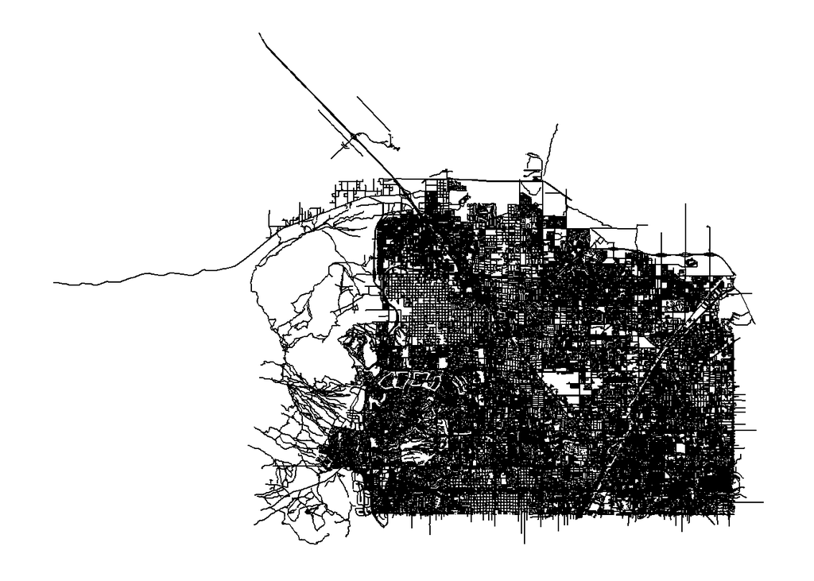

```r
ggplot(lv_streets) +
  geom_sf() +
  theme_map()
```

# Set up Open Trip Planner

I will download a little Java utility called otp.jar and save it to the OPT directory we’ve created.

```r
 path_otp <- otp_dl_jar("OTP")
```

Now I will build a graph. This is a representation of the street and transit networks.

```r
path_data <- file.path(getwd(), "OTP")
path_otp <- paste(path_data, "otp.jar", sep = "/")

otp_build_graph(otp = path_otp, dir = path_data)
```

I will launch Open Trip Planner.

```r
otp_setup(otp = path_otp, dir = path_data)
```

```
## 2020-10-08 01:12:48 OTP is loading and may take a while to be useable
```

```
## Router http://localhost:8080/otp/routers/default exists
```

```
## 2020-10-08 01:13:49 OTP is ready to use Go to localhost:8080 in your browser to view the OTP
```

Connect to open trip planner

```r
otpcon <- otp_connect()
```

```
## Router http://localhost:8080/otp/routers/default exists
```

# Create isochrones

```r
iso_10min_walk <-
  otp_isochrone(otpcon = otpcon, fromPlace = LV_polling, mode = "WALK", cutoffSec = 600)  %>%
  st_transform(crs = Nevada_mercator) %>%
  mutate(mode = "walk")

iso_10min_drive <-
  otp_isochrone(otpcon = otpcon, fromPlace = LV_polling, mode = "CAR", cutoffSec = 600) %>%
  st_transform(crs = Nevada_mercator) %>%
  mutate(mode = "drive")

iso_10min_bike <-
  otp_isochrone(otpcon = otpcon, fromPlace = LV_polling, mode = "BICYCLE", cutoffSec = 600) %>%
  st_transform(crs = Nevada_mercator) %>%
  mutate(mode = "bike")
```

```r
iso_all_modes <- rbind(iso_10min_bike, iso_10min_drive, iso_10min_walk)
```

Now I can draw a map of these isochrones on a map. I will use a background image from Open Street Map as a base map.

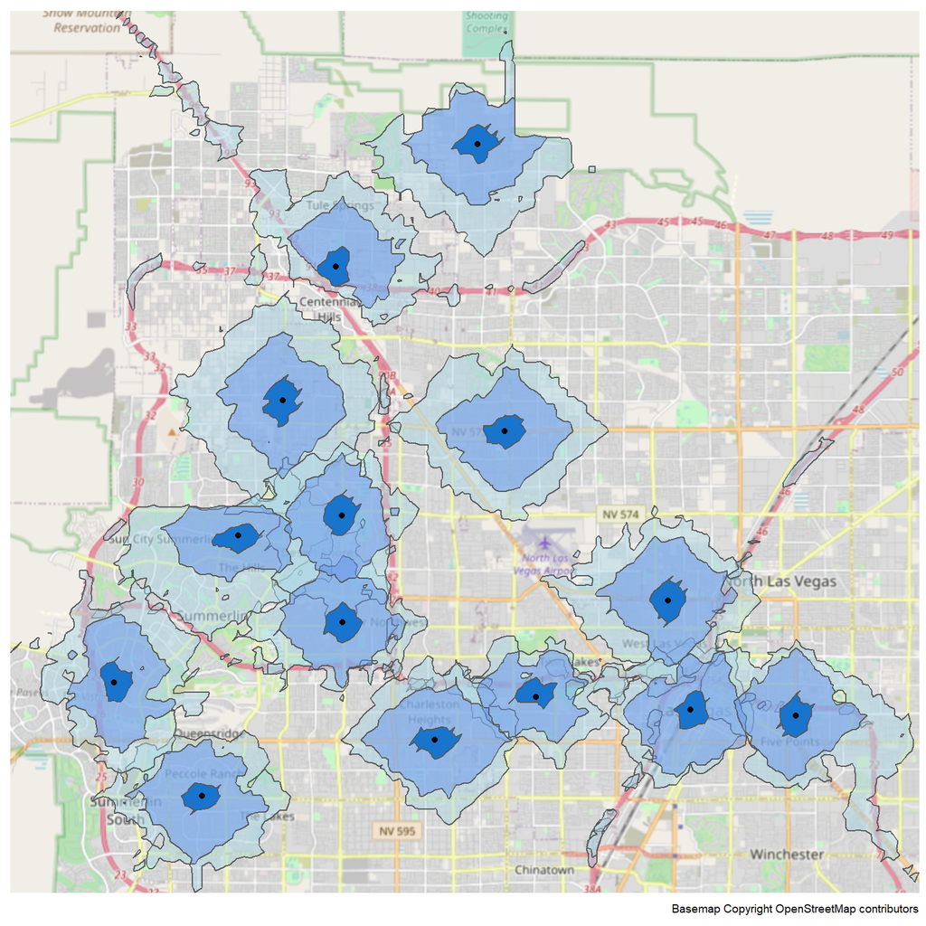

```r
right_side <- st_bbox(iso_all_modes)$xmax
left_side <- st_bbox(iso_all_modes)$xmin
top_side <- st_bbox(iso_all_modes)$ymax
bottom_side <- st_bbox(iso_all_modes)$ymin

ggplot(iso_10min_drive) +
  annotation_map_tile(zoomin = 0, progress = "none") +
  geom_sf(fill = "lightblue", alpha = 0.5) +
  geom_sf(data = iso_10min_bike, fill = "cornflowerblue", alpha = 0.5) +
  geom_sf(data = iso_10min_walk, fill = "dodgerblue3") +
  geom_sf(data = LV_polling) +
  coord_sf(xlim = c(left_side, right_side),
           ylim = c(bottom_side, top_side), expand = FALSE) +
  theme_map() +
  labs(caption = "Basemap Copyright OpenStreetMap contributors")
```

# Merged area for 10min drive isochrones

I learned this from Meghan’s html file.

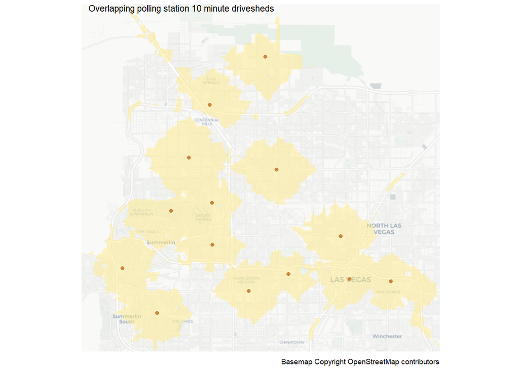

```r
total_10min_drive <- st_as_sf(st_union(iso_10min_drive$geometry))

right <- st_bbox(total_10min_drive)$xmax
left <- st_bbox(total_10min_drive)$xmin
top <- st_bbox(total_10min_drive)$ymax
bottom <- st_bbox(total_10min_drive)$ymin

ggplot(total_10min_drive) +
  annotation_map_tile(type = "cartolight", zoomin = 0, progress = "none") +
  geom_sf(fill = "lightgoldenrod1", color = NA, alpha = 0.5) +
  geom_sf(data = LV_polling, color = "tan3") +
  coord_sf(xlim = c(left, right),
           ylim = c(bottom, top), expand = FALSE) +
  annotate(geom = "text",
           x = left_side +500,
           y = top_side - 500,
           label = paste("Overlapping polling station 10 minute drivesheds"),
           hjust = 0, vjust = 0, size = 3) +
  theme_map() +
  labs(caption = "Basemap Copyright OpenStreetMap contributors")
```

```r
area <- st_area(total_10min_drive) %>%
  set_units(km^2)
area
```

```
## 201.4247 [km^2]
```

As I know that Las Vegas is of 352 km^2, 57% of the land have polling stations accessible in 10-minute drive.

# Calculate and compare isochrone areas

I will use st_area() function to calculate the area of each isochrone and visualize the relationship between the size of a walkshed and the size of a driveshed.

The function pivot_wider() creates a separate column for each value of a specified variable, so that each row represents a location (with three associated isochrones), rather than having each row represent an isochrone.

[figure not shown]

```r
iso_areas <- iso_all_modes %>%
  mutate(area = st_area(iso_all_modes)) %>%
  st_set_geometry(NULL) %>%
  pivot_wider(names_from = mode, values_from = area)

ggplot(iso_areas,
       aes(x = as.numeric(walk), y = as.numeric(drive))) +
  geom_point() +
  scale_x_continuous(name = "Area within a 10-min walking distance\nof a polling station(square km)") +
  scale_y_continuous(name = "Area within a 10-min driving distance\nof a polling station(square km)") +
  theme_economist()
```

# Polling station accessibility map

```r
nhoods <- st_read("https://opendata.arcgis.com/datasets/0629d6512c0d425badf2bd1a366aa41d_0.kml?geometry=%7B%22xmin%22%3A-115.867%2C%22ymin%22%3A36.08%2C%22xmax%22%3A-114.56%2C%22ymax%22%3A36.274%2C%22type%22%3A%22extent%22%2C%22spatialReference%22%3A%7B%22wkid%22%3A4326%7D%7D&outSR=%7B%22latestWkid%22%3A3421%2C%22wkid%22%3A102707%7D")
nhoods1 <- as(nhoods, "Spatial")
```

I will cover Las Vegas with many points around which I will create isochrones and count the number of polling stations within each of those isochrones.

```r
points <- spsample(nhoods1, n = 1000, type = "regular")
```

[figure not shown]

```r
plot(points)
```

I will make a dataframe of points.

```r
points <- st_as_sf(x = points,
                   crs = 4326)
```

I will create a 10 min driveshed around each point in “points”dataframe.

```r
iso_10min_drive_02 <-
  otp_isochrone(otpcon = otpcon, fromPlace = points, mode= "CAR", cutoffSec = 600)
```

I will count the number of polling stations in the 10min polygons.

```r
iso_10min_drive_02 <- iso_10min_drive_02 %>%
  mutate(polling_score = lengths(st_covers(geometry, LV_polling)))
```

```
## although coordinates are longitude/latitude, st_covers assumes that they are planar
```

Now we have iso_10min_drive_02 dataframe with geometry column which contains polygons, fromPlace column which contains lat, long together as a string (character), and polling_score column which is the number of polling stations in the polygon.

I will extract coordinates from fromPlace column.

```r
out <- data.frame(str_split_fixed(iso_10min_drive_02$fromPlace, ",", 2))

out <- st_as_sf(x = out,
                coords = c("X2", "X1"),
                crs = 4326)

out$polling_score <- iso_10min_drive_02$polling_score
```

I will visualize the results.

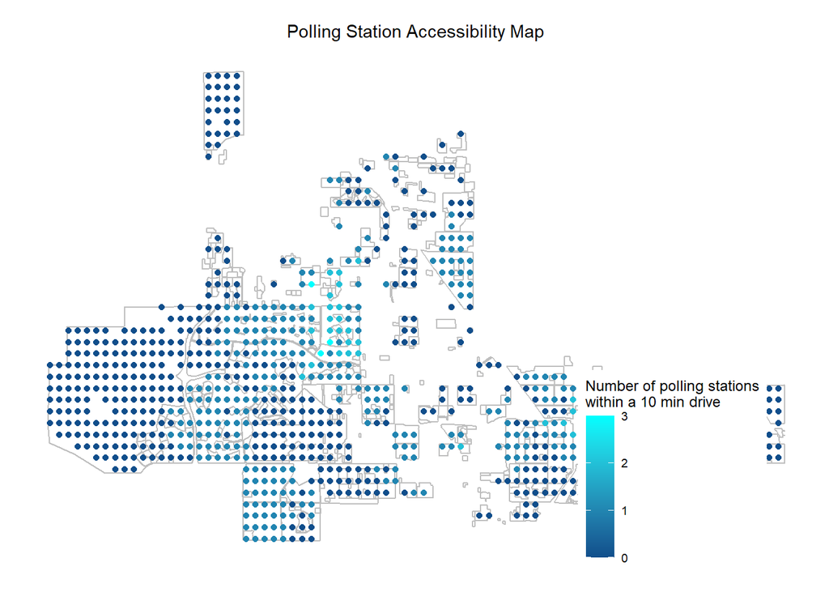

```r
ggplot(nhoods) +
  geom_sf(fill = "NA", color = "grey") +
  geom_sf(data = out,
          aes(color = polling_score)) +
  scale_color_gradientn(colors = c("dodgerblue4", "cyan1"),
                       name = "Number of polling stations\nwithin a 10 min drive") +
  theme_map() +
  theme(legend.position = c(.7,0),
        plot.title = element_text(hjust = 0.5)) +
  labs(title = "Polling Station Accessibility Map")
```

I will close the java application.

```r
otp_stop()
```